# Metropolis-Hastings

# importance sampling

$$\mathrm{E}\{h(\theta|y)\} = \frac{\int [h(\theta)q(\theta|y)/g(\theta)]g(\theta)d\theta}{\int [q(\theta|y)/g(\theta)]g(\theta)d\theta} \Longrightarrow \frac{S^{-1}\sum_{s=1}^S h(\theta^s) w(\theta^s) }{S^{-1}\sum_{s=1}^S w(\theta^s) }, w(\theta^s) = \frac{q(\theta^s|y)}{g(\theta^s)}$$
effective sample size
$$S_{\mbox{eff}} = \frac{1}{\sum_{s=1}^S (\hat{w}(\theta^s))^2 }$$

sampling-importance resampling (SIR)

- sample $\{\theta^1,\dots,\theta^S\}$ from $g(\theta)$
- sample without replacement $k<S$ $\theta$ from $\{\theta^1,\dots,\theta^S\}$ with probability proportional to $w(\theta^s) = \frac{q(\theta^s|y)}{g(\theta^s)}$

target $0.7(5,3) + 0.3(6,10)

envelope $\mbox{U}(0,1)$

```r
> nsamp <- 200
> x <- runif(nsamp, 0, 1)
> # weights
> w <- (0.7 * dbeta(x, 5, 3) + 0.3 * dbeta(x, 6, 10)) / dunif(x, 0, 1)
> # standardize
> wstd <- w / sum(w)
>
> # population mean
> 0.7 * (5 / (5 + 3)) + 0.3 * (6 / (6 + 10))
```

```
[1] 0.55
```

```r
> # sample mean
> y <- numeric(nsamp)
> for (i in 1:nsamp) {
+   if (runif(1, 0, 1) <= 0.7) {
+     y[i] <- rbeta(1, 5, 3)
+   } else  {
+     y[i] <- rbeta(1, 6, 10)
+   }
+ }
> mean(y)
```

```
[1] 0.5633487
```

```r
> # importance sampling
> # estimand g(x) = x
> mean(x * w)
```

```
[1] 0.4673346
```

```r
> sum(x * wstd)
```

```
[1] 0.5407171
```

# Metropolis algorithm

- a symmetric proposal distribution. uniform($\theta^{(s)}-\delta,\theta^{(s)}+\delta$), normal($\theta^{(s)},\delta^2$)
1. sample $\theta^* \sim J(\theta|\theta^{(s)})$
2. compute acceptance ratio
   $$r=\frac{p(\theta^*|y)}{p(\theta^{(s)}|y)}=\frac{p(y|\theta^*)p(\theta^*)}{p(y|\theta^{(s)})p(\theta^{(s)})}$$
3. let
   $$\theta^{(s+1)}=\begin{cases} \theta^* & \mbox{with probability }\min(r,1)\\
   \theta^{(s)}& \mbox{with probability }1-\min(r,1)\end{cases}$$

example
$$\begin{aligned}
y_1,\dots,y_n |\theta &\overset{i.i.d.}{\sim} \mathrm{normal}(\theta,\sigma^2)\\
\theta &\sim \mathrm{normal}(\mu,\tau^2)\\
\theta|\sigma^2,y_1,\dots,y_n &\sim \mathrm{normal}(\mu_n,\tau_n^2)
\end{aligned}$$

$\mu_n=\frac{\mu_0/\tau_0^2 + {n}\bar{y}/{\sigma^2}}{{1}/{\tau_0^2} + {n}/{\sigma^2}}$ and $\tau_n^2 = \frac{1}{{1}/{\tau_0^2} + {n}/{\sigma^2}}$

normal proposal $\theta^* \sim \mathrm{normal}(\theta^{(s)},\delta^2)$

$$\log r = \sum [\mbox{log dnorm}(y,\theta^*,\sigma) - \mbox{log dnorm}(y,\theta^{(s)},\sigma)]
+ \mbox{log dnorm}(\theta^*,\mu,\tau) - \mbox{log dnorm}(\theta^{(s)},\mu,\tau)$$

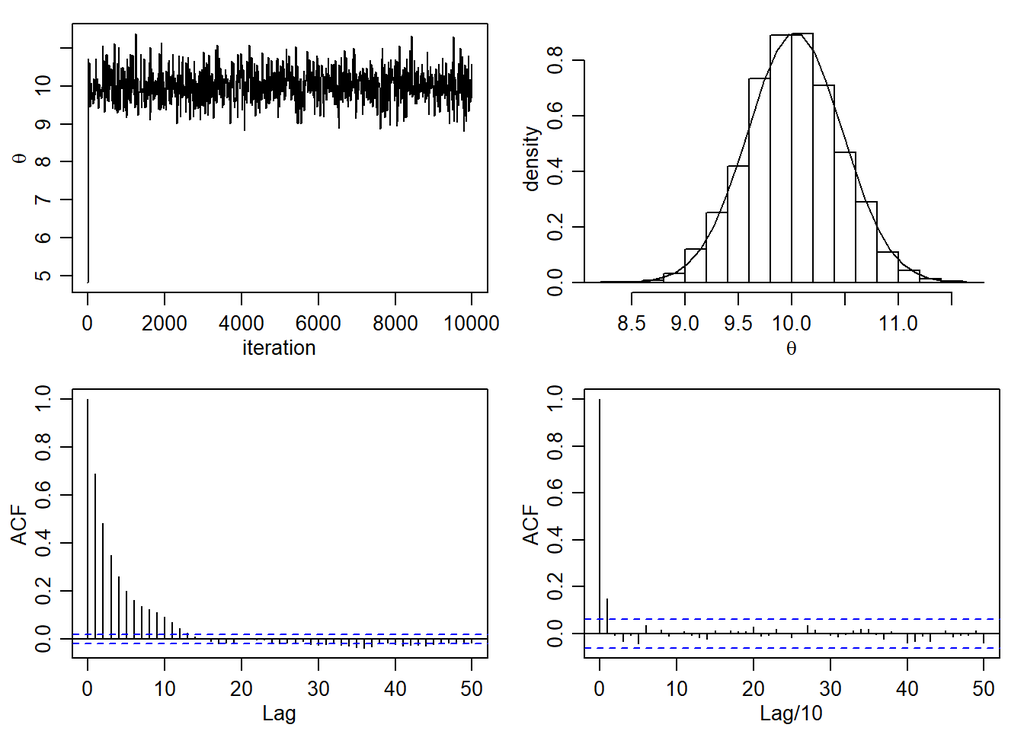

```r
> # Fig 10.3 Results from the Metropolis algorithm for the normal model
> # http://www2.stat.duke.edu/~pdh10/FCBS/Replication/chapter10.R
>
> s2 <- 1
> t2 <- 10 ; mu <- 5
>
> set.seed(1)
> n <- 5
> # y <- round(rnorm(n,10,1),2)
> y <- c(9.37, 10.18, 9.16, 11.60, 10.33)
>
> mu_n <- ( mean(y)*n/s2 + mu/t2 ) / ( n/s2 + 1/t2 )
> t2_n <- 1 / (n/s2+1/t2)
>
> delta <-2 ; nsamp <- 10000
>
> # initialization
> theta <- 0 ;  vtehta <- numeric(nsamp)
>
> for(s in 1:nsamp) {
+
+   theta_star <- rnorm(1, theta, sqrt(delta))
+
+   log.r <- ( sum( dnorm(y, theta_star, sqrt(s2), log = TRUE) ) +
+                dnorm(theta_star, mu, sqrt(t2), log = TRUE) )  -
+             ( sum( dnorm(y, theta, sqrt(s2), log = TRUE) ) +
+                 dnorm(theta, mu, sqrt(t2), log = TRUE) )
+
+   if (log(runif(1)) < log.r) { theta <- theta_star }
+
+   vtehta[s] <- theta
+
+ }
>
> par(mfrow = c(2,2), mar = c(3,3,1,1), mgp = c(1.75,.75,0))
>
> by10 <- seq(10, nsamp, by = 10)
> plot( by10, vtehta[by10], type = "l", xlab = "iteration", ylab = expression(theta) )
>
> hist( vtehta[-(1:50)], prob = TRUE, main = "", xlab = expression(theta), ylab = "density" )
> th <- seq(min(vtehta), max(vtehta), length = 100)
> lines( th, dnorm(th, mu_n, sqrt(t2_n)) )
>
> acf(vtehta, lag.max = 50)
> thin<-c(1,(1:1000)*(nsamp/1000))
> acf(vtehta[thin], lag.max = 50, xlab="Lag/10")
>
> library(coda)
```

```r
> effectiveSize(vtehta)
```

```
    var1
1427.451
```

show convergence

- small step $\rightarrow$ high correlation
- large step $\rightarrow$ high rejection

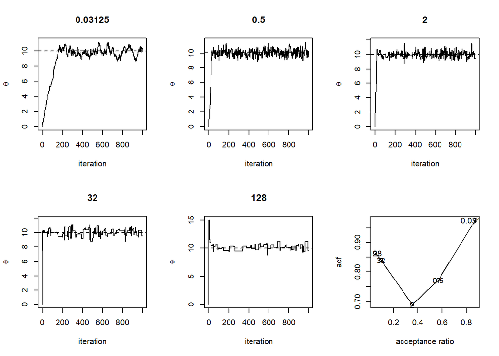

```r
> par(mfrow=c(2,3))
> vacr <- vacf <- numeric(5)
> nsamp <- 10000
>
> vdelta2 <- 2^c(-5,-1,1,5,7)
>
> for( k in 1:5 ) {
+
+   set.seed(1)
+   delta2 <- vdelta2[k]
+   vtheta <- numeric(nsamp)
+   theta <- 0
+   cnt_ac <- 0
+
+   for(s in 1:nsamp) {
+
+     theta_star <- rnorm(1, theta, sqrt(delta2))
+     log.r <- sum( dnorm(y, theta_star, sqrt(s2), log = TRUE) -
+                   dnorm(y, theta, sqrt(s2), log = TRUE) ) +
+               dnorm(theta_star, mu, sqrt(t2), log = TRUE) -
+                 dnorm(theta, mu, sqrt(t2), log = TRUE)
+
+     if ( log(runif(1)) < log.r )  { theta <- theta_star ; cnt_ac <- cnt_ac + 1 }
+     vtehta[s] <- theta
+
+   }
+
+   plot( vtehta[1:1000], type = "l", xlab = "iteration", ylab = expression(theta),
+         ylim = range(vtehta), main = delta2 )
+   abline(h = mu_n, lty = 2)
+
+   vacr[k] <- cnt_ac/nsamp
+   vacf[k] <- acf(vtehta, plot=FALSE)$acf[2]
+ }
>
> # acceptance ratio vs acf
> plot(vacr, vacf, xlab ="acceptance ratio", ylab = "acf")
> lines(vacr, vacf)
>
> for (k in 1:5) {
+   text(vacr[k], vacf[k], vdelta2[k])
+ }
```

# Metropolis-Hastings algorithm

1. update $U$:
- 1. sample from a proposal distribution (jumping distribution) $u \sim J_u(u|u^{(s)}, v^{(s)})$
- 2. compute the acceptance ratio
     $$r = \frac{p_0(u^*,v^{(s)})}{p_0(u^{(s)},v^{(s)})}\frac{J_u(u^{(s)}|u^*,v^{(s)})}{J_u(u^*{(s)}|u^{(s)},v^{(s)})}$$
- 3. set
     $$u^{(s+1)} = \begin{cases} u^* & \mbox{ with probability } \min(1,r)\\
     u^{(s)} & \mbox{ with probability } 1-\min(1,r)\end{cases}$$
2. update $V$ :
- 1. sample $v \sim J_v(v|u^{(s+1)}, v^{(s)})$
- 2. compute the acceptance ratio
     $$r = \frac{p_0(u^{(s+1)},v^*)}{p_0(u^{(s+1)},v^{(s)})}\frac{J_v(v^{(s)}|u^{(s+1)},v^*)}{J_v(v^*|u^{(s+1)},v^{(s)})}$$
- 3. set
     $$v^{(s+1)} = \begin{cases} v^* & \mbox{ with probability } \min(1,r)\\
     v^{(s)} & \mbox{ with probability } 1-\min(1,r)\end{cases}$$
- independent Metropolis-Hastings - independent proposal $J_u(u^{(s+1)}|u^{(s)},v^{(s)}) = J_u(u^{(s+1)})$
- random-walk Metropolis - Metropolis algorithm - symetric proposal distribution $J_u(u|u',v) = J_u(u'|u,v)$
  - efficient jumping rule: $J(\theta^8|\theta^{t-1}) = \mathrm{dnorm}(\theta^*;\theta^{t-1},c^2\Sigma)$, where $\Sigma$ is the known posterior variance, the most efficient scale $c \approx 2.4/\sqrt{d}$
  - multidimensional Metropolis algorithm is optimal efficient when its acceptance rate is approximately 23%
  - adaptive algorithm: adaptive phase is biased. use the fixed phase
- Gibbs sampler - full condition distribution proposal $J_u(u'|u,v) = p_0(u'|v)$
  - reparameterization, auxiliary variables (data augmentation), parameter expansion
  - BUGS (Bayesian inference Using Gibbs Sampling)
1. discard the first half as a aconservative choice
2. thin the sequence by keeping evety $k$th simulation draw due to denpendence such that the total number of iterations saved is n o more than 1000
3. split each saved sequence into two parts ($m$ chains of length $n$) to assess mixing
   $$\begin{aligned}
   \mbox{between-sequence variation }B &= \frac{n}{m-1} \sum_{j=1}^m(\bar{\psi}_{.j} - \bar{\psi}_{..})^2, \mbox{ where }\bar{\psi}_{.j} = \frac{1}{n}\sum_{i=1}^m\bar{\psi}_{ij}, \bar{\psi}_{..} = \frac{1}{m}\sum_{j=1}^m\bar{\psi}_{.j}\\
   \mbox{within-sequence variation }W &= \frac{1}{m} \sum_{j=1}^m s_j^2, \mbox{ where }s_{j}^2 = \frac{1}{n-1}\sum_{i=1}^m(\bar{\psi}_{ij}- \bar{\psi}_{.j})^2 \\
   \widehat{\mbox{Var}}^+ &= \frac{1}{n}B + \frac{n-1}{n}W\\
   \mbox{potential scale reduction } \hat{R} &= \sqrt{\frac{\widehat{\mbox{Var}}^+}{W}}\\
   \mbox{effective size }\hat{n}_{\mbox{eff}} &= \frac{mn}{1+ 2\sum_{t=1}^T\hat{\rho}_t}, \mbox{ where }T\mbox{ is the first odd positive integer for which }\hat{\rho}_{T+1}+\hat{\rho}_{T+2} \mbox{ is negative }\\
   \hat{\rho}_t &= 1- \frac{V_t}{2\widehat{\mbox{Var}}^+}\quad \mbox{from E}[({\psi}_{i,j}- {\psi}_{i-t,j})^2]=2(1-\rho_t)\mbox{Var}(\psi)\\
   \mbox{varigram } V_t &= \frac{1}{m(n-t)}\sum_{i=t+1}^n\sum_{j=1}^m({\psi}_{i,j}- {\psi}_{i-t,j})^2 \\
   \Bigg(\lim\limits_{n\to\infty} mn \mbox{Var}(\bar{\psi}_{..}) &= \left[1+ 2\sum_{t=1}^{\infty}{\rho}_t\right]\mbox{Var}(\psi|y)\Longrightarrow n_{\mbox{eff}} = \frac{\mbox{Var}(\psi|y)}{\mbox{Var}(\bar{\psi}_{..})} = \frac{mn}{1+ 2\sum_{t=1}^{\infty}{\rho}_t}\Bigg)
   \end{aligned}$$
   transform sequence distributed far from normal before computing $\hat{R}$ and $\hat{n}_{\mbox{eff}}$ for better perfromance of mean and variance-based convergernce diagnostics
4. stop until $\hat{R}$ near 1 (1.1 as a threshold) and $\hat{n}_{\mbox{eff}} \ge 5m$. Then collect the $nm$ simulations

# Hamiltonian Monte Carlo

1. update momentum $\phi \sim N(0,M)$
2. $L$ leapfrog step
   - half-step update momentum $\phi \leftarrow \phi + \frac{1}{2}\epsilon\frac{d \log p(\theta|y)}{d\theta}$
   - update position $\theta \leftarrow \theta + \epsilon M^{-1}\phi$
   - half-step update momentum $\phi \leftarrow \phi + \frac{1}{2}\epsilon\frac{d \log p(\theta|y)}{d\theta}$
3. accept-reject step $r = \frac{p(\theta^*|y)p(\theta^*)}{p(\theta^{t-1}|y)p(\phi^{t-1})}$
   $$\theta^t = \begin{cases}\theta^* &\mbox{with probability }\min(r,1)\\
   \theta^{t-1}&\mbox{otherwise}\end{cases}$$

$\epsilon L =1$ ($\epsilon =01,\ L=10$)

HMC is optimal efficient when its acceptance rate is approximately 65%

Stan (Sampling through adaptive neighborhoods)

$$\begin{aligned}
X &\sim \mathrm{norm}(\mu,\sigma^2)\\
\mu &\sim \mathrm{beta}(2,2)\\
\sigma^2 &\sim \mathrm{lognormal}(1,10)
\end{aligned}$$

```r
> x <- c(2.366,2.495,1.084,0.759,0.878,1.276,1.460,0.180,-1.01,1.487,-0.119,0.258)
```

## independent MH with prior proposal $p(\theta^*) = J_{\theta}(\theta^*)$

$$r=\frac{p(y|\theta^*)}{p(y|\theta^{(s)})}$$

```r
> nsamp <- 100000
> nburn <- 50000
>
> vmu <- numeric(nsamp)
> vsig2 <- numeric(nsamp)
>
> set.seed(1)
>
>
> mu <- rbeta(1, 2, 2)
> sig2 <- rlnorm(1, sqrt(10))
>
> naccept <- 0
>
> loglikelihood <- function (mu, sig2, x) {
+   return(sum(dnorm(x, mu, sqrt(sig2), log=T)) )
+ }
>
>
> for (s in 1:nsamp) {
+   mu_new <- rbeta(1, 2, 2)
+   sig2_new <- rlnorm(1, sqrt(10))
+
+   logr <- loglikelihood(mu_new, sig2_new, x) - loglikelihood(mu, sig2, x)
+
+   u <- runif(1)
+   if (logr >= log(u)) {
+     mu <- mu_new
+     sig2 <- sig2_new
+     naccept <- naccept + 1
+   }
+
+   vmu[s] <- mu
+   vsig2[s] <- sig2
+ }
>
> effectiveSize(vmu)
```

```
   var1
878.203
```

```r
> effectiveSize(vsig2)
```

```
    var1
1223.509
```

```r
> naccept/nsamp
```

```
[1] 0.02551
```

```r
> median(vmu)
```

```
[1] 0.6364326
```

```r
> median(vmu[(nburn+1):nsamp])
```

```
[1] 0.6246554
```

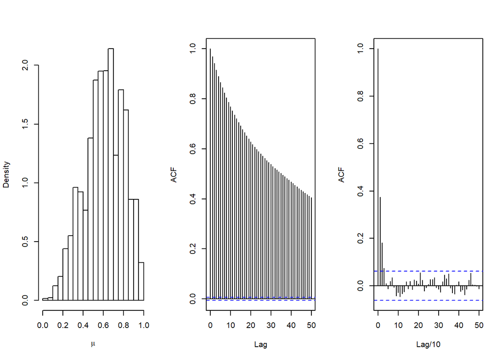

```r
> par(mfrow = c(1,3))
> hist(vmu[(nburn+1):nsamp], xlab = expression(mu),  main = "", freq = F)
> acf(vmu, lag.max = 50,  main = "")
> thin<-c(1,(1:1000)*((nsamp-nburn)/1000))
> acf(vmu[(nburn+1):nsamp][thin], lag.max = 50, xlab="Lag/10",  main = "")
```

## independent MH with general proposal

$$r=\frac{p(y|\theta^*)p(\theta^*)}{p(y|\theta^{(s)})p(\theta^{(s)})} \frac{J_{\theta}(\theta^{(s)})}{J_{\theta}(\theta^*)}$$

```r
> nsamp <- 100000
> nburn <- 50000
>
> vmu <- numeric(nsamp)
> vsig2 <- numeric(nsamp)
>
> set.seed(1)
>
> mu <- rbeta(1, 2, 2)
> sig2 <- rlnorm(1, sqrt(10))
>
> naccept <- 0
>
> logpost <- function (mu, sig2, x) {
+   return( sum(dnorm(x, mu, sqrt(sig2), log=T)) + dbeta(mu, 2, 2, log=T) +
+             dlnorm(sig2, 1, sqrt(10), log=T) )
+ }
>
>
> for (s in 1:nsamp) {
+   mu_new <- runif(1)
+   sig2_new <- rchisq(1, 1)
+
+   logr <- logpost(mu_new, sig2_new, x) - logpost(mu, sig2, x) +
+     dchisq(sig2,1, log=T) - dchisq(sig2_new,1, log=T)
+
+   u <- runif(1)
+   if (logr >= log(u)) {
+     mu <- mu_new
+     sig2 <- sig2_new
+     naccept <- naccept + 1
+   }
+
+   vmu[s] <- mu
+   vsig2[s] <- sig2
+ }
>
> effectiveSize(vmu)
```

```
    var1
12713.03
```

```r
> effectiveSize(vsig2)
```

```
    var1
15140.68
```

```r
> naccept/nsamp
```

```
[1] 0.20383
```

```r
> median(vmu)
```

```
[1] 0.67965
```

```r
> median(vmu[(nburn+1):nsamp])
```

```
[1] 0.6813197
```

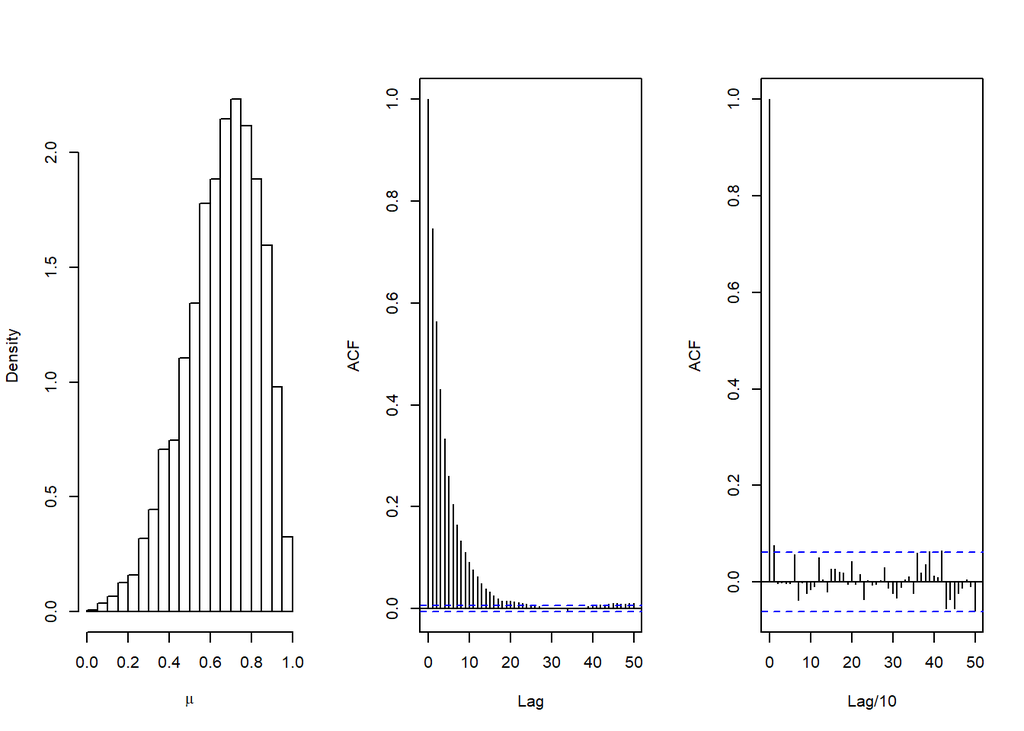

```r
> par(mfrow = c(1,3))
> hist(vmu[(nburn+1):nsamp], xlab = expression(mu),  main = "", freq = F)
> acf(vmu, lag.max = 50,  main = "")
> thin<-c(1,(1:1000)*((nsamp-nburn)/1000))
> acf(vmu[(nburn+1):nsamp][thin], lag.max = 50, xlab="Lag/10",  main = "")
```

## if omit ratio of proposal

```r
> nsamp <- 100000
> nburn <- 50000
>
> vmu <- numeric(nsamp)
> vsig2 <- numeric(nsamp)
>
> set.seed(1)
>
> mu <- rbeta(1, 2, 2)
> sig2 <- rlnorm(1, sqrt(10))
>
> naccept <- 0
>
> logpost <- function (mu, sig2, x) {
+   return( sum(dnorm(x, mu, sqrt(sig2), log=T)) + dbeta(mu, 2, 2, log=T) +
+             dlnorm(sig2, 1, sqrt(10), log=T) )
+ }
>
>
> for (s in 1:nsamp) {
+   mu_new <- runif(1)
+   sig2_new <- rchisq(1, 1)
+
+   logr <- logpost(mu_new, sig2_new, x) - logpost(mu, sig2, x)
+
+   u <- runif(1)
+   if (logr >= log(u)) {
+     mu <- mu_new
+     sig2 <- sig2_new
+     naccept <- naccept + 1
+   }
+
+   vmu[s] <- mu
+   vsig2[s] <- sig2
+ }
>
> effectiveSize(vmu)
```

```
    var1
11116.81
```

```r
> effectiveSize(vsig2)
```

```
    var1
12145.59
```

```r
> naccept/nsamp
```

```
[1] 0.1758
```

```r
> median(vmu)
```

```
[1] 0.6969797
```

```r
> median(vmu[(nburn+1):nsamp])
```

```
[1] 0.6956991
```

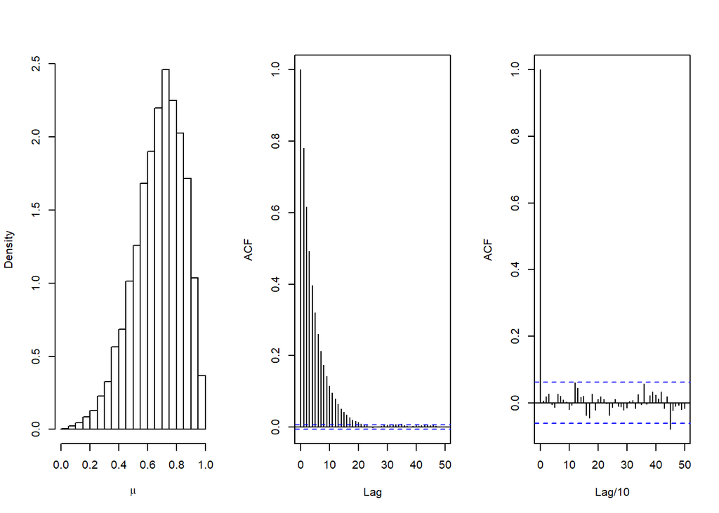

```r
> par(mfrow = c(1,3))
> hist(vmu[(nburn+1):nsamp], xlab = expression(mu),  main = "", freq = F)
> acf(vmu, lag.max = 50,  main = "")
> thin<-c(1,(1:1000)*((nsamp-nburn)/1000))
> acf(vmu[(nburn+1):nsamp][thin], lag.max = 50, xlab="Lag/10",  main = "")
```

# random walk MH $J_{\theta}(\theta^*|\theta^{(s)}) = J_{\theta}(\theta^{(s)}|\theta^*)$

$$r=\frac{p(\theta^*|y)}{p(\theta^{(s)}|y)}=\frac{p(y|\theta^*)p(\theta^*)}{p(y|\theta^{(s)})p(\theta^{(s)})}$$

```r
> nsamp <- 100000
> nburn <- 50000
>
> vmu <- numeric(nsamp)
> vlogsig2 <- numeric(nsamp)
>
> set.seed(1)
>
> mu <- rbeta(1, 2, 2)
> logsig2 <- rnorm(1, sqrt(10))
>
> delta_mu <- 0.5
> delta_logsig2 <- 5
>
> naccept <- 0
>
> logpost <- function (mu, logsig2, x) {
+   return( sum(dnorm(x, mu, sqrt(exp(logsig2)), log=T)) + dbeta(mu, 2, 2, log=T) +
+             dnorm(logsig2, 1, sqrt(10), log=T) )
+ }
>
>
> for (s in 1:nsamp) {
+   repeat {
+         mu_new <- mu + runif(1,-delta_mu,delta_mu)
+         if (mu_new >= 0 & mu_new <= 1)
+           break
+   }
+
+   logsig2_new <- rnorm(1,logsig2, delta_logsig2)
+
+   logr <- logpost(mu_new, logsig2_new, x) - logpost(mu, logsig2, x) +
+     log(min(1,mu+delta_mu)-max(0,mu-delta_mu)) -
+     log(min(1,mu_new+delta_mu)-max(0,mu_new-delta_mu))
+
+   u <- runif(1)
+   if (logr >= log(u)) {
+     mu <- mu_new
+     logsig2 <- logsig2_new
+     naccept <- naccept + 1
+   }
+
+   vmu[s] <- mu
+   vlogsig2[s] <- logsig2
+ }
>
> effectiveSize(vmu)
```

```
    var1
3656.838
```

```r
> effectiveSize(exp(vlogsig2))
```

```
   var1
5845.11
```

```r
> naccept/nsamp
```

```
[1] 0.08299
```

```r
> median(vmu)
```

```
[1] 0.671955
```

```r
> median(vmu[(nburn+1):nsamp])
```

```
[1] 0.6713271
```

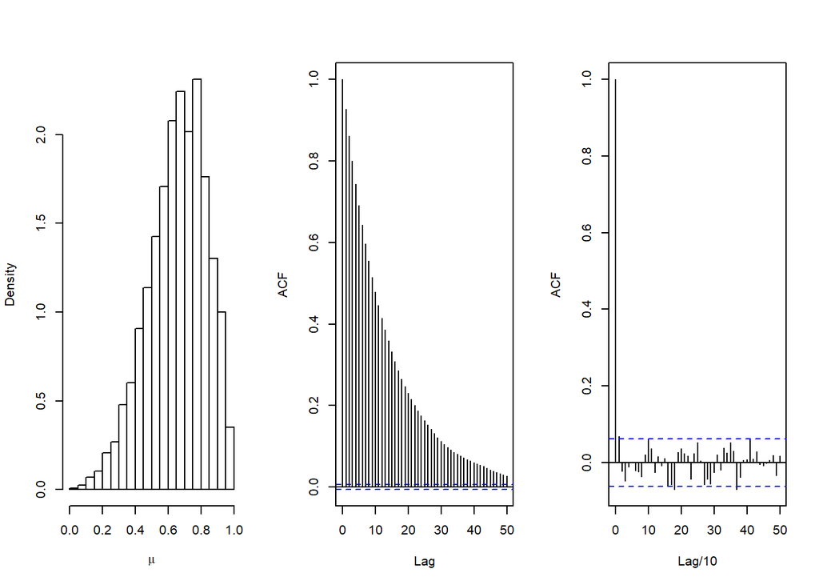

```r
> par(mfrow = c(1,3))
> hist(vmu[(nburn+1):nsamp], xlab = expression(mu),  main = "", freq = F)
> acf(vmu, lag.max = 50,  main = "")
> thin<-c(1,(1:1000)*((nsamp-nburn)/1000))
> acf(vmu[(nburn+1):nsamp][thin], lag.max = 50, xlab="Lag/10",  main = "")
```

```r
> nsamp <- 100000
> nburn <- 50000
>
> vmu <- numeric(nsamp)
> vsig2 <- numeric(nsamp)
>
> set.seed(1)
>
> mu <- rbeta(1, 2, 2)
> sig2 <- rlnorm(1, sqrt(10))
>
> delta_mu <- 0.5
> delta_sig2 <- 5
>
> naccept <- 0
>
> logpost <- function (mu, sig2, x) {
+   return( sum(dnorm(x, mu, sqrt(sig2), log=T)) + dbeta(mu, 2, 2, log=T) +
+             dlnorm(sig2, 1, sqrt(10), log=T) )
+ }
>
>
> for (s in 1:nsamp) {
+   repeat {
+         mu_new <- rnorm(1,mu,delta_mu)
+         if (mu_new >= 0 & mu_new <= 1)
+           break
+   }
+
+   repeat {
+         sig2_new <- rnorm(1,sig2,delta_sig2)
+         if (sig2_new > 0)
+           break
+   }
+
+
+   logr <- logpost(mu_new, sig2_new, x) - logpost(mu, sig2, x) +
+       log(pnorm(1,mu,delta_mu)-pnorm(0,mu,delta_mu)) -
+       log(pnorm(1,mu_new,delta_mu)-pnorm(0,mu_new,delta_mu)) +
+       log(1-pnorm(0,sig2,delta_sig2)) -
+       log(1-pnorm(0,sig2_new,delta_sig2))
+
+   u <- runif(1)
+   if (logr >= log(u)) {
+     mu <- mu_new
+     sig2 <- sig2_new
+     naccept <- naccept + 1
+   }
+
+   vmu[s] <- mu
+   vsig2[s] <- sig2
+ }
>
> effectiveSize(vmu)
```

```
   var1
6646.77
```

```r
> effectiveSize(vsig2)
```

```
    var1
7085.968
```

```r
> naccept/nsamp
```

```
[1] 0.13586
```

```r
> median(vmu)
```

```
[1] 0.6801212
```

```r
> median(vmu[(nburn+1):nsamp])
```

```
[1] 0.6816259
```

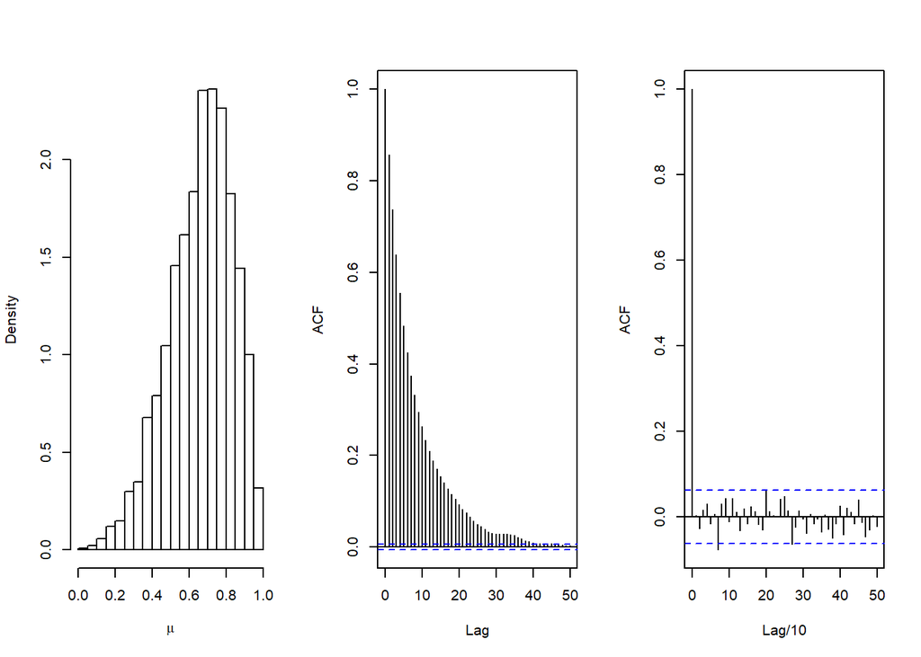

```r
> par(mfrow = c(1,3))
> hist(vmu[(nburn+1):nsamp], xlab = expression(mu),  main = "", freq = F)
> acf(vmu, lag.max = 50,  main = "")
> thin<-c(1,(1:1000)*((nsamp-nburn)/1000))
> acf(vmu[(nburn+1):nsamp][thin], lag.max = 50, xlab="Lag/10",  main = "")
```

# independent MH $\mu$ and random walk MH $\log(\sigma^2)$

```r
> nsamp <- 100000
> nburn <- 50000
>
> vmu <- numeric(nsamp)
> vlogsig2 <- numeric(nsamp)
>
> set.seed(1)
>
> mu <- rbeta(1, 2, 2)
> logsig2 <- rnorm(1, sqrt(10))
>
>
> delta_logsig2 <- 5
>
> naccept <- 0
>
> logpost <- function (mu, logsig2, x) {
+   return( sum(dnorm(x, mu, sqrt(exp(logsig2)), log=T)) + dbeta(mu, 2, 2, log=T) +
+             dnorm(logsig2, 1, sqrt(10), log=T) )
+ }
>
>
> for (s in 1:nsamp) {
+   mu_new <- runif(1)
+   logsig2_new <- rnorm(1,logsig2, delta_logsig2)
+
+   logr <- logpost(mu_new, logsig2_new, x) - logpost(mu, logsig2, x)
+
+   u <- runif(1)
+   if (logr >= log(u)) {
+     mu <- mu_new
+     logsig2 <- logsig2_new
+     naccept <- naccept + 1
+   }
+
+   vmu[s] <- mu
+   vlogsig2[s] <- logsig2
+ }
>
> effectiveSize(vmu)
```

```
   var1
3937.31
```

```r
> effectiveSize(exp(vlogsig2))
```

```
    var1
4806.368
```

```r
> naccept/nsamp
```

```
[1] 0.06895
```

```r
> median(vmu)
```

```
[1] 0.6776655
```

```r
> median(vmu[(nburn+1):nsamp])
```

```
[1] 0.6787322
```

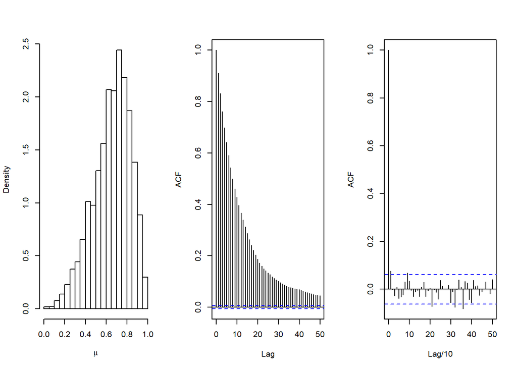

```r
> par(mfrow = c(1,3))
> hist(vmu[(nburn+1):nsamp], xlab = expression(mu),  main = "", freq = F)
> acf(vmu, lag.max = 50,  main = "")
> thin<-c(1,(1:1000)*((nsamp-nburn)/1000))
> acf(vmu[(nburn+1):nsamp][thin], lag.max = 50, xlab="Lag/10",  main = "")
```